# Greatest impact events in United States

## Synopsis

In this report we aim to point out the events that had the greatest impact in United States, both in the population and economy during the period 1950-2011. To this point we have obtained the NOAA Storm Database dataset. From this data, we have singled out the 5 events that had the greatest impact in 4 categories: number of fatalities and number of injuries as the indicators of risk to population health and total amount of property damage ($) and total amount of crop damage($) as indicators of economic risk.

## Loading and processing the raw data

### Reading the data

First we read the 902297 observations of the csv dataset. The NA fields are indicated as blank fields and we choose to not automatically convert character fields into factors since most data is encoded in character vectors. We also create a subset of the original dataset with the variables EVTYPE, FATALITIES, INJURIES, PROPDMG, PROPDMGEXP, CROPDMG and CROPDMGEXP that we are going to use in the analysis. Then the EVTYPE variable is converted into a factor.

```r
stormData<-read.csv("data/data.csv.bz2",na.strings="",
                    nrows=902297,stringsAsFactors = FALSE)
stormSS<-stormData[,c(8,23:28)]
stormSS$EVTYPE<-as.factor(stormSS$EVTYPE)
```

The PROPDMGEXP and CROPDMGEXP variables encode the factor by which the PROPDMG and CROPDMG variables have to be multiplied to obtain the monetary value of the property and crop damage, respectively. However, they have some strange values inputted that we are going to filter as follows:

- A value of B for Billions (10^9)
- A value of M or m for Millions (10^6)
- A value of K or k for Thousands (10^3)
- A value of H or h for Hundreds (10^2)
- A numeric value, n, meaning 10^n
- Other values (?,+,-) we are going to set them to NA

We also notice that the values that we set to NA are a few in the dataset.

```r
unique(stormSS$PROPDMGEXP); unique(stormSS$CROPDMGEXP)
```

```
##  [1] "K" "M" NA  "B" "m" "+" "0" "5" "6" "?" "4" "2" "3" "h" "7" "H" "-"
## [18] "1" "8"
```

```
## [1] NA  "M" "K" "m" "B" "?" "0" "k" "2"
```

```r
nrow(stormSS)
```

```
## [1] 902297
```

```r
sum(stormSS[!is.na(stormSS$PROPDMGEXP),]$PROPDMGEXP=="+")
```

```
## [1] 5
```

```r
sum(stormSS[!is.na(stormSS$PROPDMGEXP),]$PROPDMGEXP=="?")
```

```
## [1] 8
```

```r
sum(stormSS[!is.na(stormSS$PROPDMGEXP),]$PROPDMGEXP=="-")
```

```
## [1] 1
```

```r
sum(stormSS[!is.na(stormSS$CROPDMGEXP),]$CROPDMGEXP=="?")
```

```
## [1] 7
```

Now we perform the above mentioned filtering and create 2 new variables encoding the monetary value of PROPDMG and CROPDMG, PROPDMGCASH and CROPDMGCASH.

```r
stormSS$PROPDMGMULT[stormSS$PROPDMGEXP=="B"]<-10^9
stormSS$PROPDMGMULT[stormSS$PROPDMGEXP=="M"]<-10^6
stormSS$PROPDMGMULT[stormSS$PROPDMGEXP=="m"]<-10^6
stormSS$PROPDMGMULT[stormSS$PROPDMGEXP=="K"]<-10^3
stormSS$PROPDMGMULT[stormSS$PROPDMGEXP=="H"]<-10^2
stormSS$PROPDMGMULT[stormSS$PROPDMGEXP=="h"]<-10^2
stormSS$PROPDMGMULT[stormSS$PROPDMGEXP=="0"]<-10^0
stormSS$PROPDMGMULT[stormSS$PROPDMGEXP=="5"]<-10^5
stormSS$PROPDMGMULT[stormSS$PROPDMGEXP=="6"]<-10^6
stormSS$PROPDMGMULT[stormSS$PROPDMGEXP=="4"]<-10^4
stormSS$PROPDMGMULT[stormSS$PROPDMGEXP=="2"]<-10^2
stormSS$PROPDMGMULT[stormSS$PROPDMGEXP=="3"]<-10^3
stormSS$PROPDMGMULT[stormSS$PROPDMGEXP=="7"]<-10^7
stormSS$PROPDMGMULT[stormSS$PROPDMGEXP=="1"]<-10^1
stormSS$PROPDMGMULT[stormSS$PROPDMGEXP=="8"]<-10^8

stormSS$CROPDMGMULT[stormSS$CROPDMGEXP=="B"]<-10^9
stormSS$CROPDMGMULT[stormSS$CROPDMGEXP=="M"]<-10^6
stormSS$CROPDMGMULT[stormSS$CROPDMGEXP=="m"]<-10^6
stormSS$CROPDMGMULT[stormSS$CROPDMGEXP=="K"]<-10^3
stormSS$CROPDMGMULT[stormSS$CROPDMGEXP=="k"]<-10^3
stormSS$CROPDMGMULT[stormSS$CROPDMGEXP=="0"]<-10^0
stormSS$CROPDMGMULT[stormSS$CROPDMGEXP=="2"]<-10^2

stormSS$PROPDMGCASH<-stormSS$PROPDMG*stormSS$PROPDMGMULT
stormSS$CROPDMGCASH<-stormSS$CROPDMG*stormSS$CROPDMGMULT
```

## Results

### Most harmful events to population health

In this section we are going to highlight the most harmful events to population health using the variables FATALITIES and INJURIES from our dataset. Using the package *dplyr* we sum the variables by the event types encoded in EVTYPE. (Note: we are also computing the sums for the variables PROPDMGCASH and CROPDMGCASH that we are going to use in the next section).

```r
library(dplyr)
stormSum<-stormSS %>% group_by(EVTYPE) %>%
        summarise(fatalities=sum(FATALITIES),injuries=sum(INJURIES),
                  propdmg=sum(PROPDMGCASH),cropdmg=sum(CROPDMGCASH))
```

And we subset the top 5 events in each indicator

```r
fatalities<-stormSum[order(stormSum$fatalities,decreasing = T),][1:5,c(1,2)]#fatalities
injuries<-stormSum[order(stormSum$injuries,decreasing = T),][1:5,c(1,3)]#injuries
fatalities; injuries
```

```
## # A tibble: 5 × 2
##           EVTYPE fatalities
##           <fctr>      <dbl>
## 1        TORNADO       5633
## 2 EXCESSIVE HEAT       1903
## 3    FLASH FLOOD        978
## 4           HEAT        937
## 5      LIGHTNING        816
```

```
## # A tibble: 5 × 2
##           EVTYPE injuries
##           <fctr>    <dbl>
## 1        TORNADO    91346
## 2      TSTM WIND     6957
## 3          FLOOD     6789
## 4 EXCESSIVE HEAT     6525
## 5      LIGHTNING     5230
```

Finally we show this data in a barplot to illustrate the results

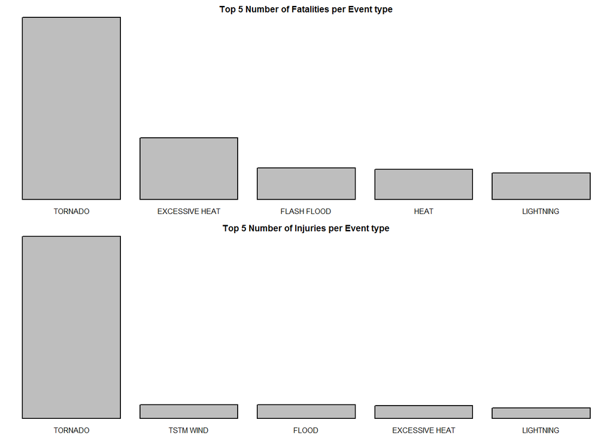

```r
par(mfrow=c(2,1))
par(cex = 0.5)
par(mar = c(2, 0, 2, 0), oma = c(0, 0, 0, 0))
par(tcl = -0.25)
par(mgp = c(2, 0.6, 0))
barplot(fatalities$fatalities,names.arg=as.array(fatalities$EVTYPE),horiz=F,yaxt='n',
        main="Top 5 Number of Fatalities per Event type")
barplot(injuries$injuries,names.arg=as.array(injuries$EVTYPE),horiz=F,yaxt='n',
        main="Top 5 Number of Injuries per Event type")
```

We can conclude that Tornadoes is the most harmful event for the population by far both in number of injuries and fatalities caused. Excessive heat and lightning also appear in both figures.

### Most harmful events to economy

As in the last section, we are going to investigate the most harmful events to the economy using the variables PROPDMGCASH and CROPDMGCASH from our dataset. Using the *stormSum* variable that we created in the last section containing the sums grouped by event type, we can show the top 5 events in each indicator.

```r
propdmg<-stormSum[order(stormSum$propdmg,decreasing = T),][1:5,c(1,4)]#propdmg
cropdmg<-stormSum[order(stormSum$cropdmg,decreasing = T),][1:5,c(1,5)]#cropdmg
propdmg; cropdmg
```

```
## # A tibble: 5 × 2
##                       EVTYPE    propdmg
##                       <fctr>      <dbl>
## 1 TORNADOES, TSTM WIND, HAIL 1600000000
## 2                 WILD FIRES  624100000
## 3                  HAILSTORM  241000000
## 4            HIGH WINDS/COLD  110500000
## 5             River Flooding  106155000
```

```
## # A tibble: 5 × 2
##                    EVTYPE   cropdmg
##                    <fctr>     <dbl>
## 1       EXCESSIVE WETNESS 142000000
## 2 COLD AND WET CONDITIONS  66000000
## 3             Early Frost  42000000
## 4         Damaging Freeze  34130000
## 5                  Freeze  10500000
```

and similarly show the data in barplots

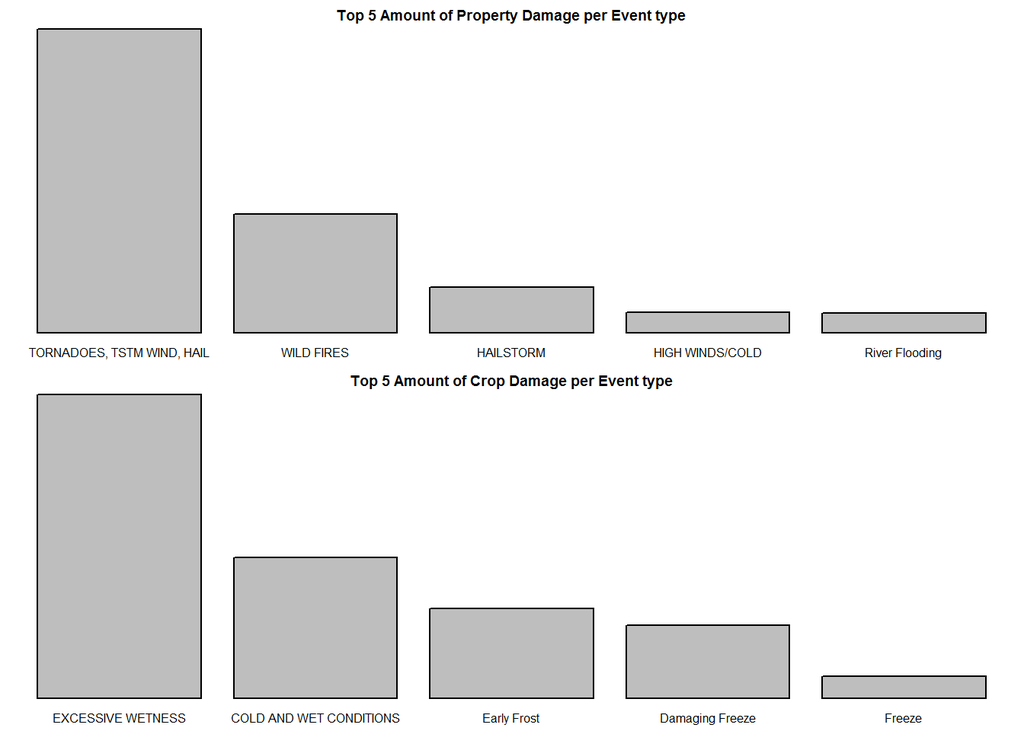

```r
par(mfrow=c(2,1))
par(cex = 0.5)
par(mar = c(2, 0, 2, 0), oma = c(0, 0, 0, 0))
par(tcl = -0.25)
par(mgp = c(2, 0.6, 0))
barplot(propdmg$propdmg,names.arg=as.array(propdmg$EVTYPE),horiz=F,yaxt='n',
        main="Top 5 Amount of Property Damage per Event type")
barplot(cropdmg$cropdmg,names.arg=as.array(cropdmg$EVTYPE),horiz=F,yaxt='n',
        main="Top 5 Amount of Crop Damage per Event type")
```

In this case “Tornadoes, Tstm Wind, Hail” was the most harmful event in terms of property damage while “Excessive Wetness” was the most harmful to crops.